# R Plot

Team Data Miners

12/3/2017

## Group Members

1. Praseeda Sasanka
2. Sowjanya
3. Zahra Hatami

# Information of Data Set

With analyzing this data and finding differences between Expected Deaths and Observed Deaths, health care can be improved by public health programs that support healthier behaviors to better access the health care services for the purpose of reducing the rate of potentially excess deaths.

## License

The License details for the Excess Deaths Data Set can be found in License Info There are no constraints on this data in regards to the license. This is public data set and can be downloaded by any individual within or outside the organization.

[License Info](https://www.cms.gov/about-cms/agency-information/aboutwebsite/privacy-policy.html)

## Metadata

This data set was collected for the years 2005-2015  
**Mortality** data for U.S. residents come from the National Vital Statistics System. Estimates based on fewer than 10 observed deaths are not shown and shaded yellow on the map.

**Underlying cause of death** is based on the International Classification of Diseases, 10th Revision (ICD-10)

Heart disease (I00-I09, I11, I13, and I20-I51)  
Cancer (C00-C97)  
Unintentional injury (V01-X59 and Y85-Y86)  
Chronic lower respiratory disease (J40-J47)  
Stroke (I60-I69)

**Locality** (nonmetropolitan vs. metropolitan) is based on the Office of Management and Budget’s 2013 county-based classification scheme.

**Benchmarks** are based on the three states with the lowest age and cause-specific mortality rates.

**Potentially excess deaths** for each state are calculated by subtracting deaths at the benchmark rates (expected deaths) from observed deaths.

Users can explore three benchmarks:

“2010 Fixed” is a fixed benchmark based on the best performing States in 2010.  
“2005 Fixed” is a fixed benchmark based on the best performing States in 2005.  
“Floating” is based on the best performing States in each year so change from year to year.

*Page last reviewed*: July 14, 2017  
*Page last updated* : August 28, 2017

## Strategies for Data Cleaning

*Steps/Strategies for cleaning data*:  
1. Analyzed the research questions and identified the required columns for analysis of Excess Deaths data set  
2. Reviewed the format of the column values in the data set to understand which command in R will be more effective to be used for this format  
3. The summary of data was obtained using R to get an overall view of the data  
4. Performed a check for missing data and found all missing data. Replaced all missing data with “NA”  
5. Tried to figure out how can we deal missing value like deleting the observations, deleting the variable, prediction or imputation with mean/median/mode. By keen observation of the data, decision was taken to delete the observations as the incomplete data cannot be of much use for the analysis. There are enormous number of observations in the data set, where all the classifications are sufficiently represented in the data. For example, having the details of locality, age, cause of death without the metrics like Expected Deaths, Potentially Excess Deaths is of not much use for analysis  
6. Checked the format of the data set to see which kind of command is needed to use in R and executed those commands in R Studio  
7. We also found few duplicate values in the data set and deleted them using R command

## Issues during Data Cleaning

Below are the issues faced during cleaning the data set

1. As this was the first time, all the team members are using R for data analysis, it took us time to get familiar with R. For example, creation of block for the code to run and closing the block before running the code
2. Another issue was, we had the age range as 0-59, 0-64, 0-74 and so on but with the same locality, state and year. Initially, the team felt this might be redundant data. But later, when we looked at the total population values, the numbers kept increasing for each range. So, we finally reviewed the description of the data in the CDC website and understood that the age ranges were always kept at standard minimum value ‘0’. As there is no redundancy we didn’t delete any data. But modified the age ranges to start from a non-zero number like 0-54 is replaced with 50-54.
3. Deciding on which method to follow for the missing data was not an easy task. It consumed a lot of time too.

## License Information of GitHub Repository

MIT License

Copyright (c) 2017 PraseedaSasankaPisipati

Permission is hereby granted, free of charge, to any person obtaining a copy of this software and associated documentation files (the “Software”), to deal in the Software without restriction, including without limitation the rights to use, copy, modify, merge, publish, distribute, sublicense, and/or sell copies of the Software, and to permit persons to whom the Software is furnished to do so, subject to the following conditions:

The above copyright notice and this permission notice shall be included in all copies or substantial portions of the Software.

THE SOFTWARE IS PROVIDED “AS IS”, WITHOUT WARRANTY OF ANY KIND, EXPRESS OR IMPLIED, INCLUDING BUT NOT LIMITED TO THE WARRANTIES OF MERCHANTABILITY, FITNESS FOR A PARTICULAR PURPOSE AND NONINFRINGEMENT. IN NO EVENT SHALL THE AUTHORS OR COPYRIGHT HOLDERS BE LIABLE FOR ANY CLAIM, DAMAGES OR OTHER LIABILITY, WHETHER IN AN ACTION OF CONTRACT, TORT OR OTHERWISE, ARISING FROM, OUT OF OR IN CONNECTION WITH THE SOFTWARE OR THE USE OR OTHER DEALINGS IN THE SOFTWARE.

### R Script for Summary Statistics and Data Cleaning

NCHS_New1 <- read.csv(“NCHS.csv”)

str(NCHS_New1)

summary(NCHS_New1)

aft_mis_NCHS_New1<-na.omit(NCHS_New1)

aft_mis_NCHS_New2<- aft_mis_NCHS_New1[!(aft_mis_NCHS_New1$State == “United States”),]

aft_mis_NCHS_New3<- aft_mis_NCHS_New2[!(aft_mis_NCHS_New2$Locality == “All”),]

dat <- aft_mis_NCHS_New3

str(dat)

summary(dat)

library(noncensus)

data(“states”)

Reg <- states[,c(1,3)]

Health_data <- merge(dat,Reg,by.x = “State.FIPS.Code”,by.y = “state”)

summary(Health_data)

##### **Summary of Variables**

summary(Health_data$Expected.Deaths) summary(Health_data$Potentially.Excess.Deaths)  
summary(Health_data$Observed.Deaths)

##### **Importing dplyr library**

suppressMessages(library(dplyr))

##### **Standard Deviation of data by Column**

sd_expected_deaths = sd(Health_data$Expected.Deaths) sd_excess_deaths = sd(Health_data$Potentially.Excess.Deaths)  
sd_observed_deaths = sd(Health_data$Observed.Deaths)

sd_expected_deaths_by_state = aggregate( Expected.Deaths ~ State, Health_data, mean )  
sd_excess_deaths_by_state = aggregate( Potentially.Excess.Deaths ~ State, Health_data, mean)  
sd_observed_deaths_by_state = aggregate(Observed.Deaths ~ State, Health_data, mean)

##### Anova table

Anova.aov= aov(Health_data$Expected.Deaths~ Health_data$Cause.of.Death)  
Anova.aov  
summary(Anova.aov)

##### Linear Regression

Regression<-lm(Health_data$Expected.Deaths ~ Health_data$Cause.of.Death + Health_data$Population)  
summary(Regression)

```
## 'data.frame':    205920 obs. of  13 variables:
##  $ Year                             : int  2005 2005 2005 2005 2005 2005 2005 2005 2005 2005 ...
##  $ Cause.of.Death                   : Factor w/ 5 levels "Cancer","CLR Disease",..: 1 1 1 1 1 1 1 1 1 1 ...
##  $ State                            : Factor w/ 52 levels "Alabama","Alaska",..: 1 1 1 1 1 1 1 1 1 1 ...
##  $ State.FIPS.Code                  : Factor w/ 52 levels "0","AK","AL",..: 3 3 3 3 3 3 3 3 3 3 ...
##  $ HHS.Region                       : int  4 4 4 4 4 4 4 4 4 4 ...
##  $ Age.Range                        : Factor w/ 8 levels "0-49","50-54",..: 1 1 1 1 1 1 1 1 1 2 ...
##  $ Benchmark                        : Factor w/ 3 levels "2005 Fixed","2010 Fixed",..: 1 1 1 2 2 2 3 3 3 1 ...
##  $ Locality                         : Factor w/ 3 levels "All","Metropolitan",..: 1 2 3 1 2 3 1 2 3 1 ...
##  $ Observed.Deaths                  : int  756 556 200 756 556 200 756 556 200 1346 ...
##  $ Population                       : int  3148377 2379871 768506 3148377 2379871 768506 3148377 2379871 768506 3463216 ...
##  $ Expected.Deaths                  : int  451 341 111 421 318 103 451 341 111 784 ...
##  $ Potentially.Excess.Deaths        : int  305 217 89 335 238 97 305 217 89 562 ...
##  $ Percent.Potentially.Excess.Deaths: Factor w/ 841 levels "","0%","0.10%",..: 355 332 397 395 380 437 355 332 397 370 ...
```

```
##       Year                   Cause.of.Death         State
##  Min.   :2005   Cancer              :41184   Alabama   :  3960
##  1st Qu.:2007   CLR Disease         :41184   Alaska    :  3960
##  Median :2010   Heart Disease       :41184   Arizona   :  3960
##  Mean   :2010   Stroke              :41184   Arkansas  :  3960
##  3rd Qu.:2013   Unintentional Injury:41184   California:  3960
##  Max.   :2015                                Colorado  :  3960
##                                              (Other)   :182160
##  State.FIPS.Code    HHS.Region       Age.Range          Benchmark
##  0      :  3960   Min.   : 0.000   0-49   :25740   2005 Fixed:68640
##  AK     :  3960   1st Qu.: 3.000   50-54  :25740   2010 Fixed:68640
##  AL     :  3960   Median : 5.000   55-59  :25740   Floating  :68640
##  AR     :  3960   Mean   : 5.231   60-64  :25740
##  AZ     :  3960   3rd Qu.: 8.000   65-69  :25740
##  CA     :  3960   Max.   :10.000   70-74  :25740
##  (Other):182160                    (Other):51480
##             Locality     Observed.Deaths    Population
##  All            :68640   Min.   :    10   Min.   :    55536
##  Metropolitan   :68640   1st Qu.:   155   1st Qu.:   682826
##  Nonmetropolitan:68640   Median :   508   Median :  1610936
##                          Mean   :  2975   Mean   :  7008421
##                          3rd Qu.:  1586   3rd Qu.:  4681585
##                          Max.   :493526   Max.   :315131659
##                          NA's   :10212    NA's   :5280
##  Expected.Deaths  Potentially.Excess.Deaths
##  Min.   :     2   Min.   :     0.0
##  1st Qu.:    92   1st Qu.:    41.0
##  Median :   298   Median :   159.0
##  Mean   :  2113   Mean   :   875.1
##  3rd Qu.:  1019   3rd Qu.:   543.0
##  Max.   :465126   Max.   :175703.0
##  NA's   :10212    NA's   :10212
##  Percent.Potentially.Excess.Deaths
##         : 10212
##  0%     :  2492
##  50%    :  1034
##  33.30% :   874
##  25%    :   678
##  40%    :   671
##  (Other):189959
```

```
## 'data.frame':    125037 obs. of  13 variables:
##  $ Year                             : int  2005 2005 2005 2005 2005 2005 2005 2005 2005 2005 ...
##  $ Cause.of.Death                   : Factor w/ 5 levels "Cancer","CLR Disease",..: 1 1 1 1 1 1 1 1 1 1 ...
##  $ State                            : Factor w/ 52 levels "Alabama","Alaska",..: 1 1 1 1 1 1 1 1 1 1 ...
##  $ State.FIPS.Code                  : Factor w/ 52 levels "0","AK","AL",..: 3 3 3 3 3 3 3 3 3 3 ...
##  $ HHS.Region                       : int  4 4 4 4 4 4 4 4 4 4 ...
##  $ Age.Range                        : Factor w/ 8 levels "0-49","50-54",..: 1 1 1 1 1 1 2 2 2 2 ...
##  $ Benchmark                        : Factor w/ 3 levels "2005 Fixed","2010 Fixed",..: 1 1 2 2 3 3 1 1 2 2 ...
##  $ Locality                         : Factor w/ 3 levels "All","Metropolitan",..: 2 3 2 3 2 3 2 3 2 3 ...
##  $ Observed.Deaths                  : int  556 200 556 200 556 200 968 378 968 378 ...
##  $ Population                       : int  2379871 768506 2379871 768506 2379871 768506 2615416 847800 2615416 847800 ...
##  $ Expected.Deaths                  : int  341 111 318 103 341 111 590 194 574 189 ...
##  $ Potentially.Excess.Deaths        : int  217 89 238 97 217 89 379 184 394 189 ...
##  $ Percent.Potentially.Excess.Deaths: Factor w/ 841 levels "","0%","0.10%",..: 332 397 380 437 332 397 334 439 359 462 ...
##  - attr(*, "na.action")=Class 'omit'  Named int [1:10212] 507 510 513 516 519 522 525 528 531 534 ...
##   .. ..- attr(*, "names")= chr [1:10212] "507" "510" "513" "516" ...
```

```
##       Year                   Cause.of.Death       State
##  Min.   :2005   Cancer              :25842   Alabama :  2640
##  1st Qu.:2007   CLR Disease         :23619   Arkansas:  2640
##  Median :2010   Heart Disease       :25818   Georgia :  2640
##  Mean   :2010   Stroke              :23886   Illinois:  2640
##  3rd Qu.:2013   Unintentional Injury:25872   Indiana :  2640
##  Max.   :2015                                Kentucky:  2640
##                                              (Other) :109197
##  State.FIPS.Code    HHS.Region       Age.Range          Benchmark
##  AL     :  2640   Min.   : 1.000   80-84  :16170   2005 Fixed:41679
##  AR     :  2640   1st Qu.: 4.000   75-79  :16167   2010 Fixed:41679
##  GA     :  2640   Median : 5.000   70-74  :16146   Floating  :41679
##  IL     :  2640   Mean   : 5.451   65-69  :16077
##  IN     :  2640   3rd Qu.: 8.000   60-64  :15921
##  KY     :  2640   Max.   :10.000   55-59  :15597
##  (Other):109197                    (Other):28959
##             Locality     Observed.Deaths   Population
##  All            :    0   Min.   :   10   Min.   :   55536
##  Metropolitan   :65865   1st Qu.:  118   1st Qu.:  581051
##  Nonmetropolitan:59172   Median :  367   Median : 1172623
##                          Mean   : 1164   Mean   : 2802117
##                          3rd Qu.: 1083   3rd Qu.: 3139035
##                          Max.   :46471   Max.   :37625302
##
##  Expected.Deaths   Potentially.Excess.Deaths
##  Min.   :    2.0   Min.   :    0.0
##  1st Qu.:   68.0   1st Qu.:   32.0
##  Median :  209.0   Median :  119.0
##  Mean   :  826.6   Mean   :  342.9
##  3rd Qu.:  691.0   3rd Qu.:  383.0
##  Max.   :50025.0   Max.   :14020.0
##
##  Percent.Potentially.Excess.Deaths
##  0%     :  1572
##  50%    :   801
##  33.30% :   617
##  25%    :   479
##  40%    :   475
##  20%    :   420
##  (Other):120673
```

```
##  State.FIPS.Code       Year                   Cause.of.Death
##  AL     :  2640   Min.   :2005   Cancer              :25842
##  AR     :  2640   1st Qu.:2007   CLR Disease         :23619
##  GA     :  2640   Median :2010   Heart Disease       :25818
##  IL     :  2640   Mean   :2010   Stroke              :23886
##  IN     :  2640   3rd Qu.:2013   Unintentional Injury:25872
##  KY     :  2640   Max.   :2015
##  (Other):109197
##       State          HHS.Region       Age.Range          Benchmark
##  Alabama :  2640   Min.   : 1.000   80-84  :16170   2005 Fixed:41679
##  Arkansas:  2640   1st Qu.: 4.000   75-79  :16167   2010 Fixed:41679
##  Georgia :  2640   Median : 5.000   70-74  :16146   Floating  :41679
##  Illinois:  2640   Mean   : 5.451   65-69  :16077
##  Indiana :  2640   3rd Qu.: 8.000   60-64  :15921
##  Kentucky:  2640   Max.   :10.000   55-59  :15597
##  (Other) :109197                    (Other):28959
##             Locality     Observed.Deaths   Population
##  All            :    0   Min.   :   10   Min.   :   55536
##  Metropolitan   :65865   1st Qu.:  118   1st Qu.:  581051
##  Nonmetropolitan:59172   Median :  367   Median : 1172623
##                          Mean   : 1164   Mean   : 2802117
##                          3rd Qu.: 1083   3rd Qu.: 3139035
##                          Max.   :46471   Max.   :37625302
##
##  Expected.Deaths   Potentially.Excess.Deaths
##  Min.   :    2.0   Min.   :    0.0
##  1st Qu.:   68.0   1st Qu.:   32.0
##  Median :  209.0   Median :  119.0
##  Mean   :  826.6   Mean   :  342.9
##  3rd Qu.:  691.0   3rd Qu.:  383.0
##  Max.   :50025.0   Max.   :14020.0
##
##  Percent.Potentially.Excess.Deaths       region
##  0%     :  1572                    Midwest  :30897
##  50%    :   801                    Northeast:19764
##  33.30% :   617                    South    :41922
##  25%    :   479                    West     :32454
##  40%    :   475
##  20%    :   420
##  (Other):120673
```

```
##    Min. 1st Qu.  Median    Mean 3rd Qu.    Max.
##     2.0    68.0   209.0   826.6   691.0 50025.0
```

```
##    Min. 1st Qu.  Median    Mean 3rd Qu.    Max.
##     0.0    32.0   119.0   342.9   383.0 14020.0
```

```
##    Min. 1st Qu.  Median    Mean 3rd Qu.    Max.
##      10     118     367    1164    1083   46471
```

```
## Call:
##    aov(formula = Health_data$Expected.Deaths ~ Health_data$Cause.of.Death)
##
## Terms:
##                 Health_data$Cause.of.Death    Residuals
## Sum of Squares                 51826601084 549095536694
## Deg. of Freedom                          4       125032
##
## Residual standard error: 2095.624
## Estimated effects may be unbalanced
```

```
##                                Df    Sum Sq   Mean Sq F value Pr(>F)
## Health_data$Cause.of.Death      4 5.183e+10 1.296e+10    2950 <2e-16 ***
## Residuals                  125032 5.491e+11 4.392e+06
## ---
## Signif. codes:  0 '***' 0.001 '**' 0.01 '*' 0.05 '.' 0.1 ' ' 1
```

```
##
## Call:
## lm(formula = Health_data$Expected.Deaths ~ Health_data$Cause.of.Death +
##     Health_data$Population)
##
## Residuals:
##    Min     1Q Median     3Q    Max
##  -8083   -480     93    390  37693
##
## Coefficients:
##                                                  Estimate Std. Error
## (Intercept)                                     1.092e+03  1.023e+01
## Health_data$Cause.of.DeathCLR Disease          -1.710e+03  1.429e+01
## Health_data$Cause.of.DeathHeart Disease        -7.522e+02  1.396e+01
## Health_data$Cause.of.DeathStroke               -1.740e+03  1.425e+01
## Health_data$Cause.of.DeathUnintentional Injury -1.411e+03  1.396e+01
## Health_data$Population                          2.987e-04  9.796e-07
##                                                t value Pr(>|t|)
## (Intercept)                                     106.82   <2e-16 ***
## Health_data$Cause.of.DeathCLR Disease          -119.69   <2e-16 ***
## Health_data$Cause.of.DeathHeart Disease         -53.86   <2e-16 ***
## Health_data$Cause.of.DeathStroke               -122.14   <2e-16 ***
## Health_data$Cause.of.DeathUnintentional Injury -101.10   <2e-16 ***
## Health_data$Population                          304.94   <2e-16 ***
## ---
## Signif. codes:  0 '***' 0.001 '**' 0.01 '*' 0.05 '.' 0.1 ' ' 1
##
## Residual standard error: 1587 on 125031 degrees of freedom
## Multiple R-squared:  0.476,  Adjusted R-squared:  0.476
## F-statistic: 2.271e+04 on 5 and 125031 DF,  p-value: < 2.2e-16
```

### R Script Link

Below is the link to R Script which can be executed to generate the plots [R Script Link](https://github.com/PraseedaSasankaPisipati/DataMiners/blob/master/Deliverables/Final%20Git%20Package/DataMiners_Rscript_Rplot.R)

### 1.Trend of all the five leading cause of Observed deaths over time for each region

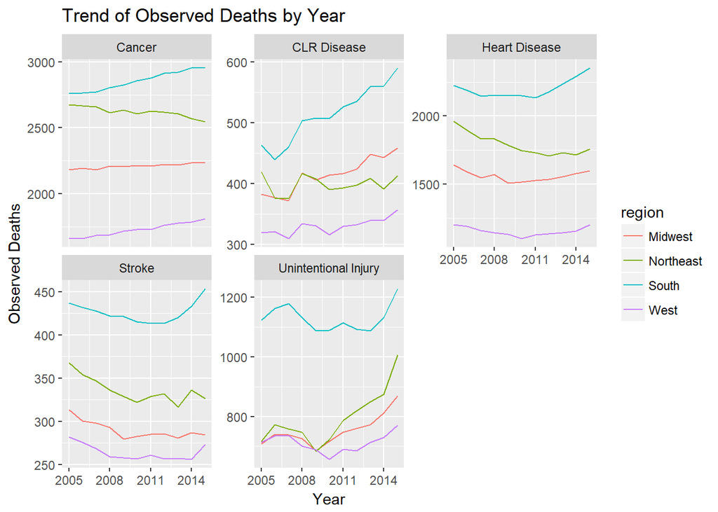

This plot provides the overview of trend for the five leading cause of deaths (observed deaths) over time. From the plot we could see that “Cancer” has the highest number of deaths and that is in the southern region of United States. The lower number of deaths could be seen for “Stroke” in the western region of United States. The order of the trends in descending order are Cancer, Heart Disease, Unintentional Injury, Chronic Lower Respiratory Disease, Stroke.

### 2. Trend of all types of deaths in Each age group

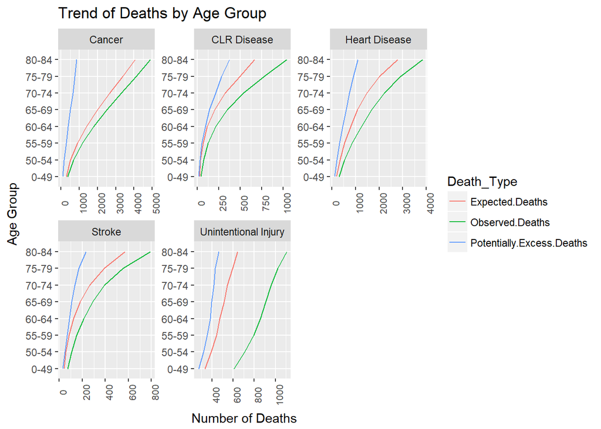

This plot provides the trend of all types of deaths for each age group. In this plot we could see that the observed deaths are always greater than the expected deaths. As the age increases the numbers of deaths kept increasing. This behavior is consistent for all the causes of death.

## 3. Comparison of all types of Deaths by region

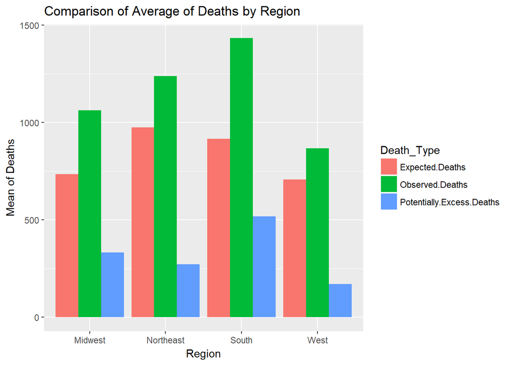

This plot gives the mean of all the deaths over various regions. The observed deaths are more in the southern part of the United States followed by Northeast, Midwest and West. The Expected Deaths average is almost equal in both South and Northeast. Midwest and West also have equal averages but lower than South and Northeast. South region also has the maximum average for potentially excess deaths followed by Midwest, Northeast and West

## 4. Comparison of all types of Deaths by locality

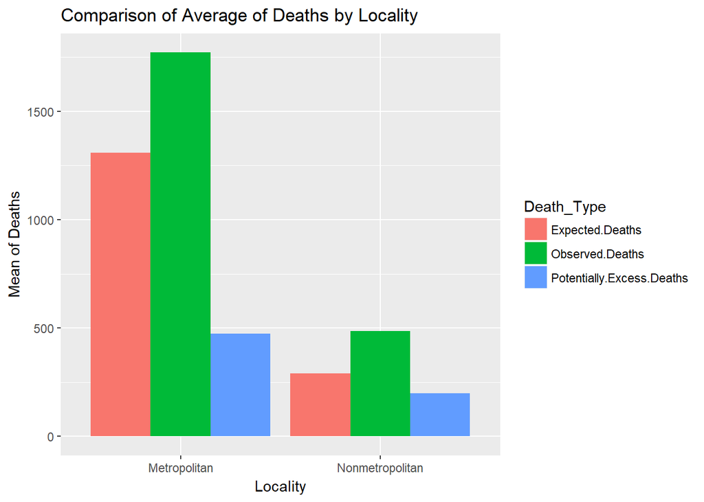

## 5. Observed deaths percentage across regions

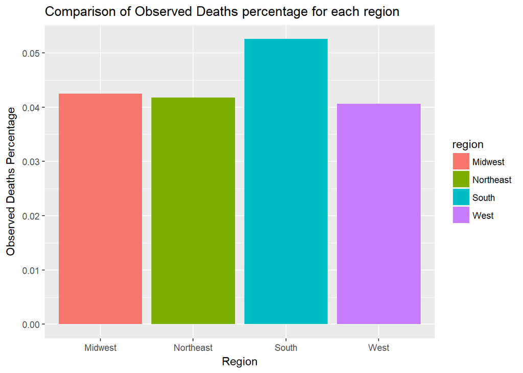

## 6. Expected Deaths percentage across regions

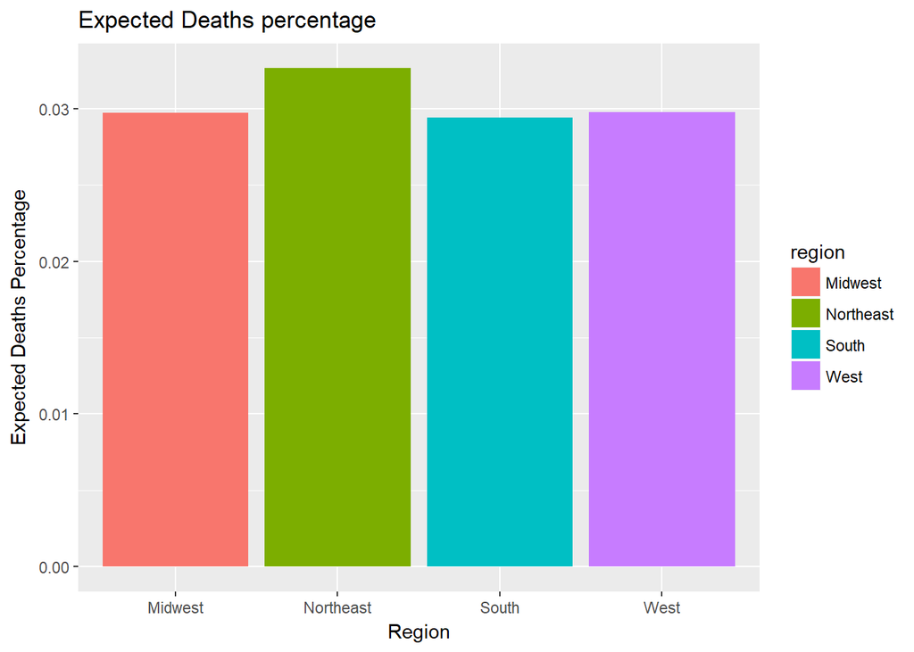

This plot is between ratio of expected deaths to population over regions. The expected death in northeast has highest rate compared with other regions. So even the expected death in northeast is greater than other regions. But as observed deaths in south of the united states is much greater than other regions, the potentially excess deaths (difference between expected death and observed death) in south of America is greater than other regions.

## 7. Correlation between both the ratios in Questions 5 and 6

```
## [1] 0.943802
```